# CondProb

Dr. B

Monday, November 03, 2014

```r
## First let's load a library
if (!require("xtable")){
        install.packages("xtable")
}
if (!require("datasets")){
        install.packages("datasets")
}

if (!require("knitr")){
        install.packages("knitr")
}
if (!require("UsingR")){
        install.packages("UsingR")
}
```

```r
## set global options
opts_chunk$set(echo=FALSE, fig.height=4, fig.width=4,warning=FALSE)
```

In line text computations. The current time is Fri Nov 11/07/14 10:23:50 PM 2014 A random number is 0.1104123

## Conditional Probabilty

Let + or - be the results of a diagnostic test, positive or negative, for a specific disease. Let D or D’ indicate if an individual has or does not have the disease.

The SENSITIVITY is the probability that the test is positive given that the individual actually has the disease, P(+|D)

The SPECIFICITY is the probability that the test is negative given that the indiviudal does not actually have the disease, P(-|D’).

The positive predictive value is the probability that the individual has the disease given that the test is positive, P(D|+).

The negative predictive value is the probabilty that the subject does not have the disease given that the test is negative, P(D’|-).

The prevalence of the disease is the marginal probability of disease, P(D).

The diagnostic likelihood ratio of a positive test, DLR+, is P(+|D)/P(+|D’) which is:

```
    sensitivity/(1-specificity)
```

The diagnostic likelihood ratio of a negative test, DLR-, is P(-|D)/P(-|D’) which is:

```
    (1-sensitivity)/specificity
```

A test for a certain disease has a sensitivity of 99.7% and a specificity of 98.5%

Suppose that an individual from a population with a .1% prevalance of the disease receives a positive test result. What us the positive predicitive value?

First calculate the DLR+

```
## [1] 66.46667
```

The results of a positive test is that the odds of disease is now 66 times the prevalance of the disease.

```
## [1] 6.646667
```

In other words, there is a 6.65% probability that the individual has the disease given the positive test result.

```
## [1] 68.51605 68.85209
```

```
## [1] 0.4627099 0.6572901
```

```
## [1] 0.4571875 0.6591640
## attr(,"conf.level")
## [1] 0.95
```

```
## [1] 0.007 0.099
```

```
## [1] 0.01721254 0.12371005
## attr(,"conf.level")
## [1] 0.95
```

```
##      2.5 %     97.5 %
## 0.01900677 0.11393446
```

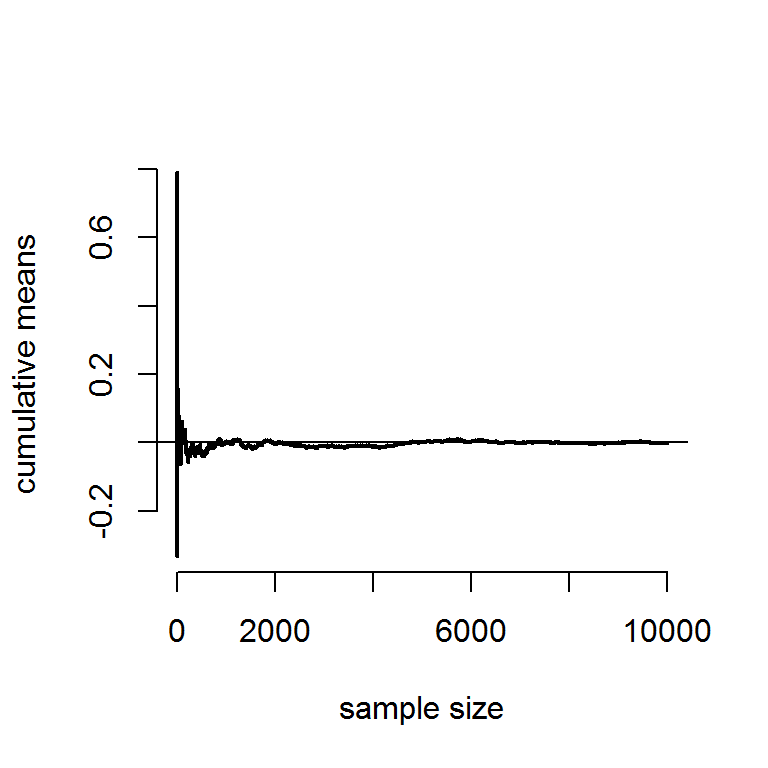

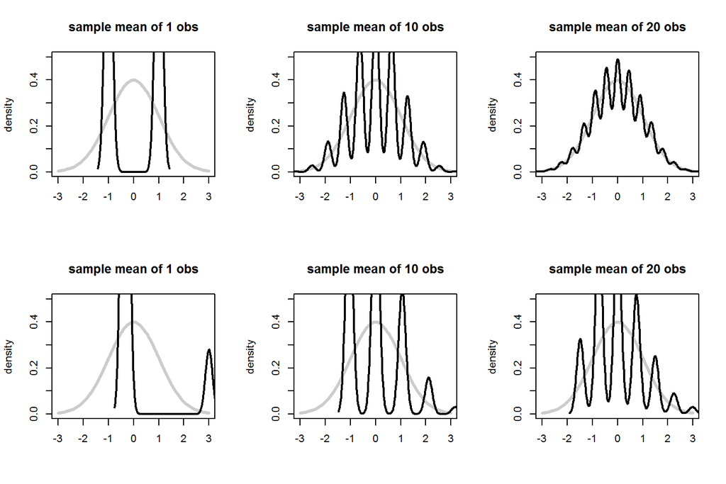

|  | Estimate | Std. Error | t value | Pr(>\|t\|) |
| --- | --- | --- | --- | --- |
| (Intercept) | -64.3421 | 23.0547 | -2.79 | 0.0062 |
| Wind | -3.3336 | 0.6544 | -5.09 | 0.0000 |
| Temp | 1.6521 | 0.2535 | 6.52 | 0.0000 |
| Solar.R | 0.0598 | 0.0232 | 2.58 | 0.0112 |